# <font color=Pink> **Name:** <font color=blue> PRASHANT VERMA </font>

```python
# Seting our local path for dataset
your_local_path = 'D:/Study_DataScience_UpXAcademy/Step-1_Python/Projects/Attachment_Project_Datasets/Project_5_Facebook_data/'
```

```python
# Check Python and other package Installation & Versions by importing each modules which will use for preparing our data.
import sys
sys.version
sys.version_info
import platform
print("Python Version: ", platform.python_version())

import pandas as pd
from pandas import Series, DataFrame

import numpy as np
from numpy.random import randn


# Importing Python Data Visualization modules which we will use for our EDA.
import seaborn as sns
import matplotlib
import matplotlib.pyplot as plt; plt.rcdefaults()


# Importing randam data selection.
import random
import pandas_profiling


# For graphs to be produced inline in the notebook itself.
%matplotlib inline


# This piece of code blocks the warning messages
import warnings
warnings.filterwarnings('ignore')
```

```
Python Version:  3.6.0
```

# <font color=Blue> **RAW Data Collection** </font>

```python
# Function for loading our data
def load_my_data(your_local_path, filename):
    return (pd.read_table(your_local_path+filename))

# Name of the file we are using.
file1 = 'pseudo_facebook.tsv'

# Loading the data using function created earlier
fbd = load_my_data(your_local_path,file1)
```

# <font color=Blue> **UpX_Facebook Dataset - Attribute Info** </font>

userid: ID of user age: User's age (years) dob_day: Day of date of birth (1-31) dob_year: Year of date of birth dob_month: Month of date of birth gender: M/F tenure: How long have facebook user been on site friend_count: Total number of friends friendships_initiated: Friend requests sent likes: Total number of likes by user likes_received: Total number of likes received by user mobile_likes: Number of likes by user (through mobile) mobile_likes_received: Number of likes received by user (through mobile) www_likes: Number of likes by user (through desktop website) www_likes_received: Number of likes received by user (through desktop)

# <font color=Blue> **UpX_Facebook Dataset - Area of Analysis** </font>

-> Date of Birth (Age) Analysis -> Friend-Count Analysis -> Tenure Analysis -> Like Analysis

# <font color=Blue> **Read, Wrangle and Initial Data Visualization** </font>

```python
# Check no. of columns and rows in the dataset.
fbd.shape
```

```
(99003, 15)
```

```python
# Check data types of each columns in the dataset.
fbd.dtypes
```

```
userid                     int64
age                        int64
dob_day                    int64
dob_year                   int64
dob_month                  int64
gender                    object
tenure                   float64
friend_count               int64
friendships_initiated      int64
likes                      int64
likes_received             int64
mobile_likes               int64
mobile_likes_received      int64
www_likes                  int64
www_likes_received         int64
dtype: object
```

```python
# Total dataset summary-1: Identifying missing samples and datatypes of each columns.
fbd.info()
```

```
<class 'pandas.core.frame.DataFrame'>
RangeIndex: 99003 entries, 0 to 99002
Data columns (total 15 columns):
userid                   99003 non-null int64
age                      99003 non-null int64
dob_day                  99003 non-null int64
dob_year                 99003 non-null int64
dob_month                99003 non-null int64
gender                   98828 non-null object
tenure                   99001 non-null float64
friend_count             99003 non-null int64
friendships_initiated    99003 non-null int64
likes                    99003 non-null int64
likes_received           99003 non-null int64
mobile_likes             99003 non-null int64
mobile_likes_received    99003 non-null int64
www_likes                99003 non-null int64
www_likes_received       99003 non-null int64
dtypes: float64(1), int64(13), object(1)
memory usage: 11.3+ MB
```

<font color=green> **Observation:** Few samples are missing in gender (175 entries) and tenure (2 entries) column. The data frame has total 15 columns. </font>

```python
# Checking duplicat values.
fbd.duplicated()
```

[output not shown]

[output cut: 47 more lines]

```python
# Show top rows
fbd.head()
```

|  | userid | age | dob_day | dob_year | dob_month | gender | tenure | friend_count | friendships_initiated | likes | likes_received | mobile_likes | mobile_likes_received | www_likes | www_likes_received |
| --- | --- | --- | --- | --- | --- | --- | --- | --- | --- | --- | --- | --- | --- | --- | --- |
| 0 | 2094382 | 14 | 19 | 1999 | 11 | male | 266.0 | 0 | 0 | 0 | 0 | 0 | 0 | 0 | 0 |
| 1 | 1192601 | 14 | 2 | 1999 | 11 | female | 6.0 | 0 | 0 | 0 | 0 | 0 | 0 | 0 | 0 |
| 2 | 2083884 | 14 | 16 | 1999 | 11 | male | 13.0 | 0 | 0 | 0 | 0 | 0 | 0 | 0 | 0 |
| 3 | 1203168 | 14 | 25 | 1999 | 12 | female | 93.0 | 0 | 0 | 0 | 0 | 0 | 0 | 0 | 0 |
| 4 | 1733186 | 14 | 4 | 1999 | 12 | male | 82.0 | 0 | 0 | 0 | 0 | 0 | 0 | 0 | 0 |

```python
# Show bottom rows
fbd.tail()
```

|  | userid | age | dob_day | dob_year | dob_month | gender | tenure | friend_count | friendships_initiated | likes | likes_received | mobile_likes | mobile_likes_received | www_likes | www_likes_received |
| --- | --- | --- | --- | --- | --- | --- | --- | --- | --- | --- | --- | --- | --- | --- | --- |
| 98998 | 1268299 | 68 | 4 | 1945 | 4 | female | 541.0 | 2118 | 341 | 3996 | 18089 | 3505 | 11887 | 491 | 6202 |
| 98999 | 1256153 | 18 | 12 | 1995 | 3 | female | 21.0 | 1968 | 1720 | 4401 | 13412 | 4399 | 10592 | 2 | 2820 |
| 99000 | 1195943 | 15 | 10 | 1998 | 5 | female | 111.0 | 2002 | 1524 | 11959 | 12554 | 11959 | 11462 | 0 | 1092 |
| 99001 | 1468023 | 23 | 11 | 1990 | 4 | female | 416.0 | 2560 | 185 | 4506 | 6516 | 4506 | 5760 | 0 | 756 |
| 99002 | 1397896 | 39 | 15 | 1974 | 5 | female | 397.0 | 2049 | 768 | 9410 | 12443 | 9410 | 9530 | 0 | 2913 |

```python
# Checking minimum age limit in dataset
fbd['age'].min()
```

```
13
```

```python
# Checking maximum age limit in dataset
fbd['age'].max()
```

```
113
```

```python
# Checking minimum tenure limit in dataset
fbd['tenure'].min()
```

```
0.0
```

```python
# Checking maximum tenure limit in dataset
fbd['tenure'].max()
```

```
3139.0
```

```python
# Description and Distribution Analysis-1: Details of raw data in each columns
fbd.describe()
```

|  | userid | age | dob_day | dob_year | dob_month | tenure | friend_count | friendships_initiated | likes | likes_received | mobile_likes | mobile_likes_received | www_likes | www_likes_received |
| --- | --- | --- | --- | --- | --- | --- | --- | --- | --- | --- | --- | --- | --- | --- |
| count | 9.900300e+04 | 99003.000000 | 99003.000000 | 99003.000000 | 99003.000000 | 99001.000000 | 99003.000000 | 99003.000000 | 99003.000000 | 99003.000000 | 99003.000000 | 99003.000000 | 99003.000000 | 99003.000000 |
| mean | 1.597045e+06 | 37.280224 | 14.530408 | 1975.719776 | 6.283365 | 537.887375 | 196.350787 | 107.452471 | 156.078785 | 142.689363 | 106.116300 | 84.120491 | 49.962425 | 58.568831 |
| std | 3.440592e+05 | 22.589748 | 9.015606 | 22.589748 | 3.529672 | 457.649874 | 387.304229 | 188.786951 | 572.280681 | 1387.919613 | 445.252985 | 839.889444 | 285.560152 | 601.416348 |
| min | 1.000008e+06 | 13.000000 | 1.000000 | 1900.000000 | 1.000000 | 0.000000 | 0.000000 | 0.000000 | 0.000000 | 0.000000 | 0.000000 | 0.000000 | 0.000000 | 0.000000 |
| 25% | 1.298806e+06 | 20.000000 | 7.000000 | 1963.000000 | 3.000000 | 226.000000 | 31.000000 | 17.000000 | 1.000000 | 1.000000 | 0.000000 | 0.000000 | 0.000000 | 0.000000 |
| 50% | 1.596148e+06 | 28.000000 | 14.000000 | 1985.000000 | 6.000000 | 412.000000 | 82.000000 | 46.000000 | 11.000000 | 8.000000 | 4.000000 | 4.000000 | 0.000000 | 2.000000 |
| 75% | 1.895744e+06 | 50.000000 | 22.000000 | 1993.000000 | 9.000000 | 675.000000 | 206.000000 | 117.000000 | 81.000000 | 59.000000 | 46.000000 | 33.000000 | 7.000000 | 20.000000 |
| max | 2.193542e+06 | 113.000000 | 31.000000 | 2000.000000 | 12.000000 | 3139.000000 | 4923.000000 | 4144.000000 | 25111.000000 | 261197.000000 | 25111.000000 | 138561.000000 | 14865.000000 | 129953.000000 |

# <font color=Blue> **Data Cleaning** </font>

## Assumption-1:

Filled missing values in gender (175 places) by mode of gender.

```python
# Missing gender values are being replace by MODE of gender.
fbd['gender'].fillna(fbd['gender'].mode()[0],inplace=True)

# Total dataset summary-2: Identifying missing samples and datatypes of each columns.
fbd.info()
```

```
<class 'pandas.core.frame.DataFrame'>
RangeIndex: 99003 entries, 0 to 99002
Data columns (total 15 columns):
userid                   99003 non-null int64
age                      99003 non-null int64
dob_day                  99003 non-null int64
dob_year                 99003 non-null int64
dob_month                99003 non-null int64
gender                   99003 non-null object
tenure                   99001 non-null float64
friend_count             99003 non-null int64
friendships_initiated    99003 non-null int64
likes                    99003 non-null int64
likes_received           99003 non-null int64
mobile_likes             99003 non-null int64
mobile_likes_received    99003 non-null int64
www_likes                99003 non-null int64
www_likes_received       99003 non-null int64
dtypes: float64(1), int64(13), object(1)
memory usage: 11.3+ MB
```

```python
# Missing tenure values are being replace by MEAN of tenure.
fbd['tenure'].fillna(fbd['tenure'].mean(),inplace=True)

# Total dataset summary-3: Identifying missing samples and datatypes of each columns.
fbd.info()
```

```
<class 'pandas.core.frame.DataFrame'>
RangeIndex: 99003 entries, 0 to 99002
Data columns (total 15 columns):
userid                   99003 non-null int64
age                      99003 non-null int64
dob_day                  99003 non-null int64
dob_year                 99003 non-null int64
dob_month                99003 non-null int64
gender                   99003 non-null object
tenure                   99003 non-null float64
friend_count             99003 non-null int64
friendships_initiated    99003 non-null int64
likes                    99003 non-null int64
likes_received           99003 non-null int64
mobile_likes             99003 non-null int64
mobile_likes_received    99003 non-null int64
www_likes                99003 non-null int64
www_likes_received       99003 non-null int64
dtypes: float64(1), int64(13), object(1)
memory usage: 11.3+ MB
```

```python
# Description and Distribution Analysis-2: Details of modified data without missing values in each columns
fbd.describe()
```

|  | userid | age | dob_day | dob_year | dob_month | tenure | friend_count | friendships_initiated | likes | likes_received | mobile_likes | mobile_likes_received | www_likes | www_likes_received |
| --- | --- | --- | --- | --- | --- | --- | --- | --- | --- | --- | --- | --- | --- | --- |
| count | 9.900300e+04 | 99003.000000 | 99003.000000 | 99003.000000 | 99003.000000 | 99003.000000 | 99003.000000 | 99003.000000 | 99003.000000 | 99003.000000 | 99003.000000 | 99003.000000 | 99003.000000 | 99003.000000 |
| mean | 1.597045e+06 | 37.280224 | 14.530408 | 1975.719776 | 6.283365 | 537.887375 | 196.350787 | 107.452471 | 156.078785 | 142.689363 | 106.116300 | 84.120491 | 49.962425 | 58.568831 |
| std | 3.440592e+05 | 22.589748 | 9.015606 | 22.589748 | 3.529672 | 457.645251 | 387.304229 | 188.786951 | 572.280681 | 1387.919613 | 445.252985 | 839.889444 | 285.560152 | 601.416348 |
| min | 1.000008e+06 | 13.000000 | 1.000000 | 1900.000000 | 1.000000 | 0.000000 | 0.000000 | 0.000000 | 0.000000 | 0.000000 | 0.000000 | 0.000000 | 0.000000 | 0.000000 |
| 25% | 1.298806e+06 | 20.000000 | 7.000000 | 1963.000000 | 3.000000 | 226.000000 | 31.000000 | 17.000000 | 1.000000 | 1.000000 | 0.000000 | 0.000000 | 0.000000 | 0.000000 |
| 50% | 1.596148e+06 | 28.000000 | 14.000000 | 1985.000000 | 6.000000 | 412.000000 | 82.000000 | 46.000000 | 11.000000 | 8.000000 | 4.000000 | 4.000000 | 0.000000 | 2.000000 |
| 75% | 1.895744e+06 | 50.000000 | 22.000000 | 1993.000000 | 9.000000 | 675.000000 | 206.000000 | 117.000000 | 81.000000 | 59.000000 | 46.000000 | 33.000000 | 7.000000 | 20.000000 |
| max | 2.193542e+06 | 113.000000 | 31.000000 | 2000.000000 | 12.000000 | 3139.000000 | 4923.000000 | 4144.000000 | 25111.000000 | 261197.000000 | 25111.000000 | 138561.000000 | 14865.000000 | 129953.000000 |

```python
# Addition of new columns for further analysis of Likes and received likes.
fbd['Mobile_Total_Likes']=fbd['mobile_likes'] + fbd['mobile_likes_received']
fbd['Desktop_Total_Likes']=fbd['www_likes'] + fbd['www_likes_received']
fbd['Total_Likes_Send']=fbd['mobile_likes'] + fbd['www_likes']
fbd['Total_Likes_Received']=fbd['mobile_likes_received'] + fbd['www_likes_received']
fbd.info()
```

```
<class 'pandas.core.frame.DataFrame'>
RangeIndex: 99003 entries, 0 to 99002
Data columns (total 19 columns):
userid                   99003 non-null int64
age                      99003 non-null int64
dob_day                  99003 non-null int64
dob_year                 99003 non-null int64
dob_month                99003 non-null int64
gender                   99003 non-null object
tenure                   99003 non-null float64
friend_count             99003 non-null int64
friendships_initiated    99003 non-null int64
likes                    99003 non-null int64
likes_received           99003 non-null int64
mobile_likes             99003 non-null int64
mobile_likes_received    99003 non-null int64
www_likes                99003 non-null int64
www_likes_received       99003 non-null int64
Mobile_Total_Likes       99003 non-null int64
Desktop_Total_Likes      99003 non-null int64
Total_Likes_Send         99003 non-null int64
Total_Likes_Received     99003 non-null int64
dtypes: float64(1), int64(17), object(1)
memory usage: 14.4+ MB
```

Overview

Dataset info

| Number of variables | 19 |
| --- | --- |
| Number of observations | 99003 |
| Total Missing (%) | 0.0% |
| Total size in memory | 14.4 MiB |
| Average record size in memory | 152.0 B |

Variables types

| Numeric | 12 |
| --- | --- |
| Categorical | 1 |
| Boolean | 0 |
| Date | 0 |
| Text (Unique) | 0 |
| Rejected | 6 |
| Unsupported | 0 |

Warnings

- `Desktop_Total_Likes` is highly correlated with `www_likes_received` (ρ = 0.92923) Rejected

- `Mobile_Total_Likes` is highly correlated with `mobile_likes_received` (ρ = 0.91523) Rejected

- `Total_Likes_Received` is highly correlated with `www_likes_received` (ρ = 0.94799) Rejected

- `Total_Likes_Send` is highly correlated with `likes` (ρ = 1) Rejected

- `friend_count` has 1962 / 2.0% zeros Zeros

- `friendships_initiated` has 2997 / 3.0% zeros Zeros

- `likes` has 22308 / 22.5% zeros Zeros

- `likes_received` is highly skewed (γ1 = 112.07) Skewed

- `likes_received` has 24428 / 24.7% zeros Zeros

- `mobile_likes` has 35056 / 35.4% zeros Zeros

- `mobile_likes_received` is highly correlated with `likes_received` (ρ = 0.97368) Rejected

- `www_likes` has 60999 / 61.6% zeros Zeros

- `www_likes_received` is highly correlated with `likes_received` (ρ = 0.94799) Rejected

Variables

Desktop_Total_Likes  
Highly correlated

*This variable is highly correlated with `www_likes_received` and should be ignored for analysis*

| Correlation | 0.92923 |
| --- | --- |

Mobile_Total_Likes  
Highly correlated

*This variable is highly correlated with `mobile_likes_received` and should be ignored for analysis*

| Correlation | 0.91523 |
| --- | --- |

Total_Likes_Received  
Highly correlated

*This variable is highly correlated with `www_likes_received` and should be ignored for analysis*

| Correlation | 0.94799 |
| --- | --- |

Total_Likes_Send  
Highly correlated

*This variable is highly correlated with `likes` and should be ignored for analysis*

| Correlation | 1 |
| --- | --- |

age  
Numeric

| Distinct count | 101 |
| --- | --- |
| Unique (%) | 0.1% |
| Missing (%) | 0.0% |
| Missing (n) | 0 |
| Infinite (%) | 0.0% |
| Infinite (n) | 0 |

| Mean | 37.28 |
| --- | --- |
| Minimum | 13 |
| Maximum | 113 |
| Zeros (%) | 0.0% |

Toggle details

**Statistics**

Quantile statistics

| Minimum | 13 |
| --- | --- |
| 5-th percentile | 15 |
| Q1 | 20 |
| Median | 28 |
| Q3 | 50 |
| 95-th percentile | 90 |
| Maximum | 113 |
| Range | 100 |
| Interquartile range | 30 |

Descriptive statistics

| Standard deviation | 22.59 |
| --- | --- |
| Coef of variation | 0.60594 |
| Kurtosis | 1.5614 |
| Mean | 37.28 |
| MAD | 17.869 |
| Skewness | 1.4153 |
| Sum | 3690854 |
| Variance | 510.3 |
| Memory size | 773.5 KiB |

**Histogram**

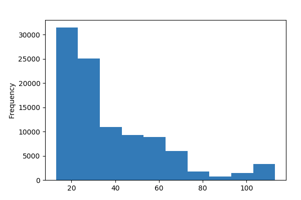

**Common Values**

| Value | Count | Frequency (%) |  |
| --- | --- | --- | --- |
| 18 | 5196 | 5.2% |  |
| 23 | 4404 | 4.4% |  |
| 19 | 4391 | 4.4% |  |
| 20 | 3769 | 3.8% |  |
| 21 | 3671 | 3.7% |  |
| 25 | 3641 | 3.7% |  |
| 17 | 3283 | 3.3% |  |
| 16 | 3086 | 3.1% |  |
| 22 | 3032 | 3.1% |  |
| 24 | 2827 | 2.9% |  |
| Other values (91) | 61703 | 62.3% |  |

**Extreme Values**

Minimum 5 values

| Value | Count | Frequency (%) |  |
| --- | --- | --- | --- |
| 13 | 484 | 0.5% |  |
| 14 | 1925 | 1.9% |  |
| 15 | 2618 | 2.6% |  |
| 16 | 3086 | 3.1% |  |
| 17 | 3283 | 3.3% |  |

Maximum 5 values

| Value | Count | Frequency (%) |  |
| --- | --- | --- | --- |
| 109 | 9 | 0.0% |  |
| 110 | 15 | 0.0% |  |
| 111 | 18 | 0.0% |  |
| 112 | 18 | 0.0% |  |
| 113 | 202 | 0.2% |  |

dob_day  
Numeric

| Distinct count | 31 |
| --- | --- |
| Unique (%) | 0.0% |
| Missing (%) | 0.0% |
| Missing (n) | 0 |
| Infinite (%) | 0.0% |
| Infinite (n) | 0 |

| Mean | 14.53 |
| --- | --- |
| Minimum | 1 |
| Maximum | 31 |
| Zeros (%) | 0.0% |

Toggle details

**Statistics**

Quantile statistics

| Minimum | 1 |
| --- | --- |
| 5-th percentile | 1 |
| Q1 | 7 |
| Median | 14 |
| Q3 | 22 |
| 95-th percentile | 29 |
| Maximum | 31 |
| Range | 30 |
| Interquartile range | 15 |

Descriptive statistics

| Standard deviation | 9.0156 |
| --- | --- |
| Coef of variation | 0.62046 |
| Kurtosis | -1.189 |
| Mean | 14.53 |
| MAD | 7.7948 |
| Skewness | 0.10784 |
| Sum | 1438554 |
| Variance | 81.281 |
| Memory size | 773.5 KiB |

**Histogram**

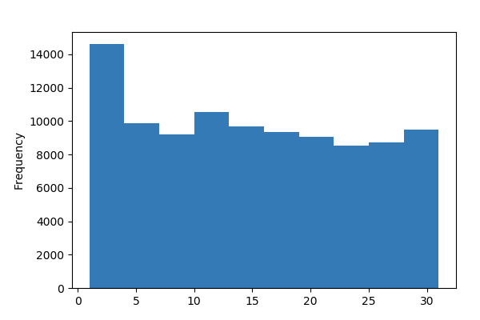

**Common Values**

| Value | Count | Frequency (%) |  |
| --- | --- | --- | --- |
| 1 | 7900 | 8.0% |  |
| 10 | 4030 | 4.1% |  |
| 15 | 3555 | 3.6% |  |
| 5 | 3545 | 3.6% |  |
| 12 | 3413 | 3.4% |  |
| 2 | 3409 | 3.4% |  |
| 3 | 3291 | 3.3% |  |
| 17 | 3266 | 3.3% |  |
| 20 | 3263 | 3.3% |  |
| 14 | 3219 | 3.3% |  |
| Other values (21) | 60112 | 60.7% |  |

**Extreme Values**

Minimum 5 values

| Value | Count | Frequency (%) |  |
| --- | --- | --- | --- |
| 1 | 7900 | 8.0% |  |
| 2 | 3409 | 3.4% |  |
| 3 | 3291 | 3.3% |  |
| 4 | 3217 | 3.2% |  |
| 5 | 3545 | 3.6% |  |

Maximum 5 values

| Value | Count | Frequency (%) |  |
| --- | --- | --- | --- |
| 27 | 2755 | 2.8% |  |
| 28 | 2955 | 3.0% |  |
| 29 | 2508 | 2.5% |  |
| 30 | 2530 | 2.6% |  |
| 31 | 1507 | 1.5% |  |

dob_month  
Numeric

| Distinct count | 12 |
| --- | --- |
| Unique (%) | 0.0% |
| Missing (%) | 0.0% |
| Missing (n) | 0 |
| Infinite (%) | 0.0% |
| Infinite (n) | 0 |

| Mean | 6.2834 |
| --- | --- |
| Minimum | 1 |
| Maximum | 12 |
| Zeros (%) | 0.0% |

Toggle details

**Statistics**

Quantile statistics

| Minimum | 1 |
| --- | --- |
| 5-th percentile | 1 |
| Q1 | 3 |
| Median | 6 |
| Q3 | 9 |
| 95-th percentile | 12 |
| Maximum | 12 |
| Range | 11 |
| Interquartile range | 6 |

Descriptive statistics

| Standard deviation | 3.5297 |
| --- | --- |
| Coef of variation | 0.56175 |
| Kurtosis | -1.2404 |
| Mean | 6.2834 |
| MAD | 3.073 |
| Skewness | 0.031296 |
| Sum | 622072 |
| Variance | 12.459 |
| Memory size | 773.5 KiB |

**Histogram**

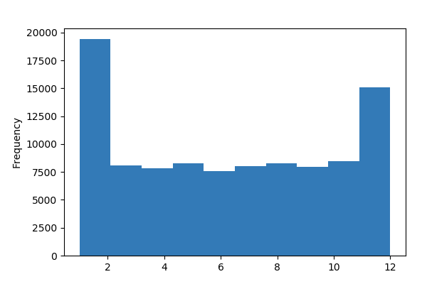

**Common Values**

| Value | Count | Frequency (%) |  |
| --- | --- | --- | --- |
| 1 | 11772 | 11.9% |  |
| 10 | 8476 | 8.6% |  |
| 5 | 8271 | 8.4% |  |
| 8 | 8266 | 8.3% |  |
| 3 | 8110 | 8.2% |  |
| 7 | 8021 | 8.1% |  |
| 9 | 7939 | 8.0% |  |
| 12 | 7894 | 8.0% |  |
| 4 | 7810 | 7.9% |  |
| 2 | 7632 | 7.7% |  |
| Other values (2) | 14812 | 15.0% |  |

**Extreme Values**

Minimum 5 values

| Value | Count | Frequency (%) |  |
| --- | --- | --- | --- |
| 1 | 11772 | 11.9% |  |
| 2 | 7632 | 7.7% |  |
| 3 | 8110 | 8.2% |  |
| 4 | 7810 | 7.9% |  |
| 5 | 8271 | 8.4% |  |

Maximum 5 values

| Value | Count | Frequency (%) |  |
| --- | --- | --- | --- |
| 8 | 8266 | 8.3% |  |
| 9 | 7939 | 8.0% |  |
| 10 | 8476 | 8.6% |  |
| 11 | 7205 | 7.3% |  |
| 12 | 7894 | 8.0% |  |

dob_year  
Numeric

| Distinct count | 101 |
| --- | --- |
| Unique (%) | 0.1% |
| Missing (%) | 0.0% |
| Missing (n) | 0 |
| Infinite (%) | 0.0% |
| Infinite (n) | 0 |

| Mean | 1975.7 |
| --- | --- |
| Minimum | 1900 |
| Maximum | 2000 |
| Zeros (%) | 0.0% |

Toggle details

**Statistics**

Quantile statistics

| Minimum | 1900 |
| --- | --- |
| 5-th percentile | 1923 |
| Q1 | 1963 |
| Median | 1985 |
| Q3 | 1993 |
| 95-th percentile | 1998 |
| Maximum | 2000 |
| Range | 100 |
| Interquartile range | 30 |

Descriptive statistics

| Standard deviation | 22.59 |
| --- | --- |
| Coef of variation | 0.011434 |
| Kurtosis | 1.5614 |
| Mean | 1975.7 |
| MAD | 17.869 |
| Skewness | -1.4153 |
| Sum | 195602185 |
| Variance | 510.3 |
| Memory size | 773.5 KiB |

**Histogram**

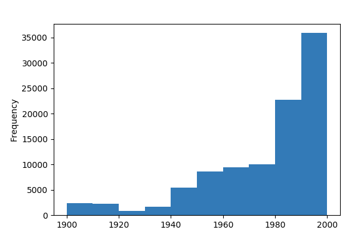

**Common Values**

| Value | Count | Frequency (%) |  |
| --- | --- | --- | --- |
| 1995 | 5196 | 5.2% |  |
| 1990 | 4404 | 4.4% |  |
| 1994 | 4391 | 4.4% |  |
| 1993 | 3769 | 3.8% |  |
| 1992 | 3671 | 3.7% |  |
| 1988 | 3641 | 3.7% |  |
| 1996 | 3283 | 3.3% |  |
| 1997 | 3086 | 3.1% |  |
| 1991 | 3032 | 3.1% |  |
| 1989 | 2827 | 2.9% |  |
| Other values (91) | 61703 | 62.3% |  |

**Extreme Values**

Minimum 5 values

| Value | Count | Frequency (%) |  |
| --- | --- | --- | --- |
| 1900 | 202 | 0.2% |  |
| 1901 | 18 | 0.0% |  |
| 1902 | 18 | 0.0% |  |
| 1903 | 15 | 0.0% |  |
| 1904 | 9 | 0.0% |  |

Maximum 5 values

| Value | Count | Frequency (%) |  |
| --- | --- | --- | --- |
| 1996 | 3283 | 3.3% |  |
| 1997 | 3086 | 3.1% |  |
| 1998 | 2618 | 2.6% |  |
| 1999 | 1925 | 1.9% |  |
| 2000 | 484 | 0.5% |  |

friend_count  
Numeric

| Distinct count | 2562 |
| --- | --- |
| Unique (%) | 2.6% |
| Missing (%) | 0.0% |
| Missing (n) | 0 |
| Infinite (%) | 0.0% |
| Infinite (n) | 0 |

| Mean | 196.35 |
| --- | --- |
| Minimum | 0 |
| Maximum | 4923 |
| Zeros (%) | 2.0% |

Toggle details

**Statistics**

Quantile statistics

| Minimum | 0 |
| --- | --- |
| 5-th percentile | 3 |
| Q1 | 31 |
| Median | 82 |
| Q3 | 206 |
| 95-th percentile | 720 |
| Maximum | 4923 |
| Range | 4923 |
| Interquartile range | 175 |

Descriptive statistics

| Standard deviation | 387.3 |
| --- | --- |
| Coef of variation | 1.9725 |
| Kurtosis | 50.094 |
| Mean | 196.35 |
| MAD | 194.33 |
| Skewness | 6.059 |
| Sum | 19439317 |
| Variance | 150000 |
| Memory size | 773.5 KiB |

**Histogram**

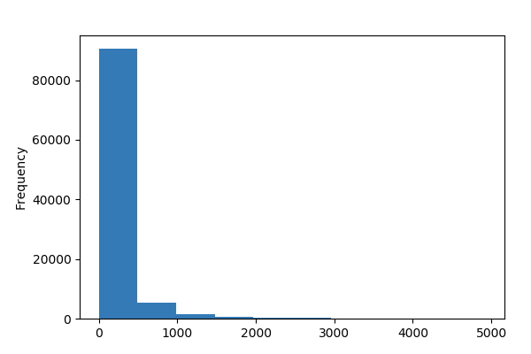

**Common Values**

| Value | Count | Frequency (%) |  |
| --- | --- | --- | --- |
| 0 | 1962 | 2.0% |  |
| 1 | 1816 | 1.8% |  |
| 2 | 1117 | 1.1% |  |
| 3 | 860 | 0.9% |  |
| 5 | 789 | 0.8% |  |
| 4 | 749 | 0.8% |  |
| 10 | 737 | 0.7% |  |
| 24 | 732 | 0.7% |  |
| 6 | 720 | 0.7% |  |
| 29 | 719 | 0.7% |  |
| Other values (2552) | 88802 | 89.7% |  |

**Extreme Values**

Minimum 5 values

| Value | Count | Frequency (%) |  |
| --- | --- | --- | --- |
| 0 | 1962 | 2.0% |  |
| 1 | 1816 | 1.8% |  |
| 2 | 1117 | 1.1% |  |
| 3 | 860 | 0.9% |  |
| 4 | 749 | 0.8% |  |

Maximum 5 values

| Value | Count | Frequency (%) |  |
| --- | --- | --- | --- |
| 4844 | 1 | 0.0% |  |
| 4845 | 1 | 0.0% |  |
| 4863 | 1 | 0.0% |  |
| 4917 | 1 | 0.0% |  |
| 4923 | 1 | 0.0% |  |

friendships_initiated  
Numeric

| Distinct count | 1519 |
| --- | --- |
| Unique (%) | 1.5% |
| Missing (%) | 0.0% |
| Missing (n) | 0 |
| Infinite (%) | 0.0% |
| Infinite (n) | 0 |

| Mean | 107.45 |
| --- | --- |
| Minimum | 0 |
| Maximum | 4144 |
| Zeros (%) | 3.0% |

Toggle details

**Statistics**

Quantile statistics

| Minimum | 0 |
| --- | --- |
| 5-th percentile | 1 |
| Q1 | 17 |
| Median | 46 |
| Q3 | 117 |
| 95-th percentile | 418 |
| Maximum | 4144 |
| Range | 4144 |
| Interquartile range | 100 |

Descriptive statistics

| Standard deviation | 188.79 |
| --- | --- |
| Coef of variation | 1.7569 |
| Kurtosis | 42.536 |
| Mean | 107.45 |
| MAD | 105.49 |
| Skewness | 5.1508 |
| Sum | 10638117 |
| Variance | 35641 |
| Memory size | 773.5 KiB |

**Histogram**

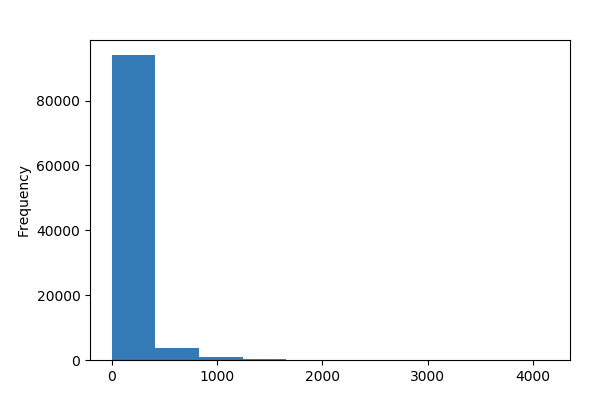

**Common Values**

| Value | Count | Frequency (%) |  |
| --- | --- | --- | --- |
| 0 | 2997 | 3.0% |  |
| 1 | 2212 | 2.2% |  |
| 2 | 1551 | 1.6% |  |
| 3 | 1355 | 1.4% |  |
| 4 | 1352 | 1.4% |  |
| 6 | 1328 | 1.3% |  |
| 5 | 1328 | 1.3% |  |
| 11 | 1319 | 1.3% |  |
| 8 | 1314 | 1.3% |  |
| 13 | 1279 | 1.3% |  |
| Other values (1509) | 82968 | 83.8% |  |

**Extreme Values**

Minimum 5 values

| Value | Count | Frequency (%) |  |
| --- | --- | --- | --- |
| 0 | 2997 | 3.0% |  |
| 1 | 2212 | 2.2% |  |
| 2 | 1551 | 1.6% |  |
| 3 | 1355 | 1.4% |  |
| 4 | 1352 | 1.4% |  |

Maximum 5 values

| Value | Count | Frequency (%) |  |
| --- | --- | --- | --- |
| 3415 | 1 | 0.0% |  |
| 3538 | 1 | 0.0% |  |
| 3594 | 1 | 0.0% |  |
| 3654 | 1 | 0.0% |  |
| 4144 | 1 | 0.0% |  |

gender  
Categorical

| Distinct count | 2 |
| --- | --- |
| Unique (%) | 0.0% |
| Missing (%) | 0.0% |
| Missing (n) | 0 |

| male | 58749 |
| --- | --- |
| female | 40254 |

Toggle details

| Value | Count | Frequency (%) |  |
| --- | --- | --- | --- |
| male | 58749 | 59.3% |  |
| female | 40254 | 40.7% |  |

likes  
Numeric

| Distinct count | 2924 |
| --- | --- |
| Unique (%) | 3.0% |
| Missing (%) | 0.0% |
| Missing (n) | 0 |
| Infinite (%) | 0.0% |
| Infinite (n) | 0 |

| Mean | 156.08 |
| --- | --- |
| Minimum | 0 |
| Maximum | 25111 |
| Zeros (%) | 22.5% |

Toggle details

**Statistics**

Quantile statistics

| Minimum | 0 |
| --- | --- |
| 5-th percentile | 0 |
| Q1 | 1 |
| Median | 11 |
| Q3 | 81 |
| 95-th percentile | 726 |
| Maximum | 25111 |
| Range | 25111 |
| Interquartile range | 80 |

Descriptive statistics

| Standard deviation | 572.28 |
| --- | --- |
| Coef of variation | 3.6666 |
| Kurtosis | 200.45 |
| Mean | 156.08 |
| MAD | 220.51 |
| Skewness | 11.024 |
| Sum | 15452268 |
| Variance | 327510 |
| Memory size | 773.5 KiB |

**Histogram**

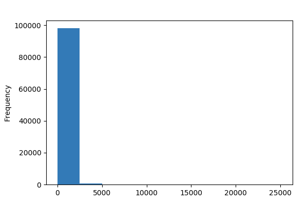

**Common Values**

| Value | Count | Frequency (%) |  |
| --- | --- | --- | --- |
| 0 | 22308 | 22.5% |  |
| 1 | 6928 | 7.0% |  |
| 2 | 4434 | 4.5% |  |
| 3 | 3240 | 3.3% |  |
| 4 | 2507 | 2.5% |  |
| 5 | 2027 | 2.0% |  |
| 6 | 1806 | 1.8% |  |
| 7 | 1618 | 1.6% |  |
| 8 | 1430 | 1.4% |  |
| 9 | 1381 | 1.4% |  |
| Other values (2914) | 51324 | 51.8% |  |

**Extreme Values**

Minimum 5 values

| Value | Count | Frequency (%) |  |
| --- | --- | --- | --- |
| 0 | 22308 | 22.5% |  |
| 1 | 6928 | 7.0% |  |
| 2 | 4434 | 4.5% |  |
| 3 | 3240 | 3.3% |  |
| 4 | 2507 | 2.5% |  |

Maximum 5 values

| Value | Count | Frequency (%) |  |
| --- | --- | --- | --- |
| 14799 | 1 | 0.0% |  |
| 16583 | 1 | 0.0% |  |
| 16732 | 1 | 0.0% |  |
| 21652 | 1 | 0.0% |  |
| 25111 | 1 | 0.0% |  |

likes_received  
Numeric

| Distinct count | 2681 |
| --- | --- |
| Unique (%) | 2.7% |
| Missing (%) | 0.0% |
| Missing (n) | 0 |
| Infinite (%) | 0.0% |
| Infinite (n) | 0 |

| Mean | 142.69 |
| --- | --- |
| Minimum | 0 |
| Maximum | 261197 |
| Zeros (%) | 24.7% |

Toggle details

**Statistics**

Quantile statistics

| Minimum | 0 |
| --- | --- |
| 5-th percentile | 0 |
| Q1 | 1 |
| Median | 8 |
| Q3 | 59 |
| 95-th percentile | 561 |
| Maximum | 261197 |
| Range | 261197 |
| Interquartile range | 58 |

Descriptive statistics

| Standard deviation | 1387.9 |
| --- | --- |
| Coef of variation | 9.7269 |
| Kurtosis | 17385 |
| Mean | 142.69 |
| MAD | 209.27 |
| Skewness | 112.07 |
| Sum | 14126675 |
| Variance | 1926300 |
| Memory size | 773.5 KiB |

**Histogram**

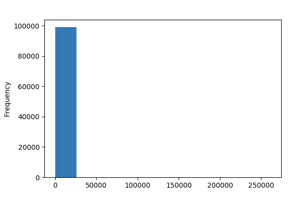

**Common Values**

| Value | Count | Frequency (%) |  |
| --- | --- | --- | --- |
| 0 | 24428 | 24.7% |  |
| 1 | 7305 | 7.4% |  |
| 2 | 4541 | 4.6% |  |
| 3 | 3347 | 3.4% |  |
| 4 | 2669 | 2.7% |  |
| 5 | 2373 | 2.4% |  |
| 6 | 1873 | 1.9% |  |
| 7 | 1680 | 1.7% |  |
| 8 | 1538 | 1.6% |  |
| 9 | 1351 | 1.4% |  |
| Other values (2671) | 47898 | 48.4% |  |

**Extreme Values**

Minimum 5 values

| Value | Count | Frequency (%) |  |
| --- | --- | --- | --- |
| 0 | 24428 | 24.7% |  |
| 1 | 7305 | 7.4% |  |
| 2 | 4541 | 4.6% |  |
| 3 | 3347 | 3.4% |  |
| 4 | 2669 | 2.7% |  |

Maximum 5 values

| Value | Count | Frequency (%) |  |
| --- | --- | --- | --- |
| 82623 | 1 | 0.0% |  |
| 106025 | 1 | 0.0% |  |
| 152014 | 1 | 0.0% |  |
| 178166 | 1 | 0.0% |  |
| 261197 | 1 | 0.0% |  |

mobile_likes  
Numeric

| Distinct count | 2396 |
| --- | --- |
| Unique (%) | 2.4% |
| Missing (%) | 0.0% |
| Missing (n) | 0 |
| Infinite (%) | 0.0% |
| Infinite (n) | 0 |

| Mean | 106.12 |
| --- | --- |
| Minimum | 0 |
| Maximum | 25111 |
| Zeros (%) | 35.4% |

Toggle details

**Statistics**

Quantile statistics

| Minimum | 0 |
| --- | --- |
| 5-th percentile | 0 |
| Q1 | 0 |
| Median | 4 |
| Q3 | 46 |
| 95-th percentile | 481.9 |
| Maximum | 25111 |
| Range | 25111 |
| Interquartile range | 46 |

Descriptive statistics

| Standard deviation | 445.25 |
| --- | --- |
| Coef of variation | 4.1959 |
| Kurtosis | 360.99 |
| Mean | 106.12 |
| MAD | 155.74 |
| Skewness | 14.161 |
| Sum | 10505832 |
| Variance | 198250 |
| Memory size | 773.5 KiB |

**Histogram**

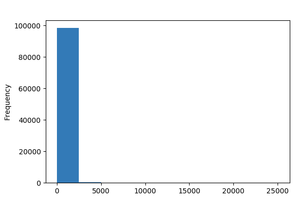

**Common Values**

| Value | Count | Frequency (%) |  |
| --- | --- | --- | --- |
| 0 | 35056 | 35.4% |  |
| 1 | 6297 | 6.4% |  |
| 2 | 3941 | 4.0% |  |
| 3 | 2917 | 2.9% |  |
| 4 | 2265 | 2.3% |  |
| 5 | 1794 | 1.8% |  |
| 6 | 1598 | 1.6% |  |
| 7 | 1395 | 1.4% |  |
| 8 | 1212 | 1.2% |  |
| 9 | 1149 | 1.2% |  |
| Other values (2386) | 41379 | 41.8% |  |

**Extreme Values**

Minimum 5 values

| Value | Count | Frequency (%) |  |
| --- | --- | --- | --- |
| 0 | 35056 | 35.4% |  |
| 1 | 6297 | 6.4% |  |
| 2 | 3941 | 4.0% |  |
| 3 | 2917 | 2.9% |  |
| 4 | 2265 | 2.3% |  |

Maximum 5 values

| Value | Count | Frequency (%) |  |
| --- | --- | --- | --- |
| 13529 | 1 | 0.0% |  |
| 14039 | 1 | 0.0% |  |
| 16732 | 1 | 0.0% |  |
| 21652 | 1 | 0.0% |  |
| 25111 | 1 | 0.0% |  |

mobile_likes_received  
Highly correlated

*This variable is highly correlated with `likes_received` and should be ignored for analysis*

| Correlation | 0.97368 |
| --- | --- |

tenure  
Numeric

| Distinct count | 2427 |
| --- | --- |
| Unique (%) | 2.5% |
| Missing (%) | 0.0% |
| Missing (n) | 0 |
| Infinite (%) | 0.0% |
| Infinite (n) | 0 |

| Mean | 537.89 |
| --- | --- |
| Minimum | 0 |
| Maximum | 3139 |
| Zeros (%) | 0.1% |

Toggle details

**Statistics**

Quantile statistics

| Minimum | 0 |
| --- | --- |
| 5-th percentile | 47 |
| Q1 | 226 |
| Median | 412 |
| Q3 | 675 |
| 95-th percentile | 1575 |
| Maximum | 3139 |
| Range | 3139 |
| Interquartile range | 449 |

Descriptive statistics

| Standard deviation | 457.65 |
| --- | --- |
| Coef of variation | 0.85082 |
| Kurtosis | 2.1992 |
| Mean | 537.89 |
| MAD | 338.65 |
| Skewness | 1.5357 |
| Sum | 53252000 |
| Variance | 209440 |
| Memory size | 773.5 KiB |

**Histogram**

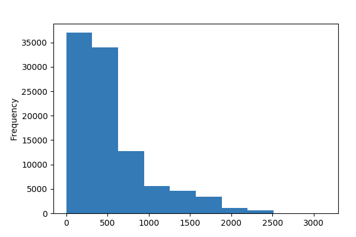

**Common Values**

| Value | Count | Frequency (%) |  |
| --- | --- | --- | --- |
| 300.0 | 173 | 0.2% |  |
| 303.0 | 170 | 0.2% |  |
| 242.0 | 164 | 0.2% |  |
| 272.0 | 163 | 0.2% |  |
| 257.0 | 161 | 0.2% |  |
| 297.0 | 161 | 0.2% |  |
| 280.0 | 160 | 0.2% |  |
| 285.0 | 160 | 0.2% |  |
| 278.0 | 158 | 0.2% |  |
| 284.0 | 158 | 0.2% |  |
| Other values (2417) | 97375 | 98.4% |  |

**Extreme Values**

Minimum 5 values

| Value | Count | Frequency (%) |  |
| --- | --- | --- | --- |
| 0.0 | 70 | 0.1% |  |
| 1.0 | 60 | 0.1% |  |
| 2.0 | 72 | 0.1% |  |
| 3.0 | 79 | 0.1% |  |
| 4.0 | 86 | 0.1% |  |

Maximum 5 values

| Value | Count | Frequency (%) |  |
| --- | --- | --- | --- |
| 3019.0 | 1 | 0.0% |  |
| 3101.0 | 1 | 0.0% |  |
| 3128.0 | 1 | 0.0% |  |
| 3129.0 | 1 | 0.0% |  |
| 3139.0 | 3 | 0.0% |  |

userid  
Numeric

| Distinct count | 99003 |
| --- | --- |
| Unique (%) | 100.0% |
| Missing (%) | 0.0% |
| Missing (n) | 0 |
| Infinite (%) | 0.0% |
| Infinite (n) | 0 |

| Mean | 1597000 |
| --- | --- |
| Minimum | 1000008 |
| Maximum | 2193542 |
| Zeros (%) | 0.0% |

Toggle details

**Statistics**

Quantile statistics

| Minimum | 1000008 |
| --- | --- |
| 5-th percentile | 1060600 |
| Q1 | 1298800 |
| Median | 1596100 |
| Q3 | 1895700 |
| 95-th percentile | 2133400 |
| Maximum | 2193542 |
| Range | 1193534 |
| Interquartile range | 596940 |

Descriptive statistics

| Standard deviation | 344060 |
| --- | --- |
| Coef of variation | 0.21543 |
| Kurtosis | -1.1996 |
| Mean | 1597000 |
| MAD | 297970 |
| Skewness | 0.00010766 |
| Sum | -801523233 |
| Variance | 118380000000 |
| Memory size | 773.5 KiB |

**Histogram**

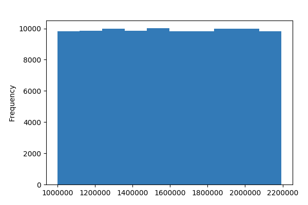

**Common Values**

| Value | Count | Frequency (%) |  |
| --- | --- | --- | --- |
| 1159224 | 1 | 0.0% |  |
| 1129202 | 1 | 0.0% |  |
| 1055510 | 1 | 0.0% |  |
| 1855227 | 1 | 0.0% |  |
| 2110369 | 1 | 0.0% |  |
| 1991449 | 1 | 0.0% |  |
| 2128666 | 1 | 0.0% |  |
| 1884335 | 1 | 0.0% |  |
| 2082123 | 1 | 0.0% |  |
| 1026848 | 1 | 0.0% |  |
| Other values (98993) | 98993 | 100.0% |  |

**Extreme Values**

Minimum 5 values

| Value | Count | Frequency (%) |  |
| --- | --- | --- | --- |
| 1000008 | 1 | 0.0% |  |
| 1000013 | 1 | 0.0% |  |
| 1000015 | 1 | 0.0% |  |
| 1000038 | 1 | 0.0% |  |
| 1000059 | 1 | 0.0% |  |

Maximum 5 values

| Value | Count | Frequency (%) |  |
| --- | --- | --- | --- |
| 2193485 | 1 | 0.0% |  |
| 2193499 | 1 | 0.0% |  |
| 2193522 | 1 | 0.0% |  |
| 2193538 | 1 | 0.0% |  |
| 2193542 | 1 | 0.0% |  |

www_likes  
Numeric

| Distinct count | 1726 |
| --- | --- |
| Unique (%) | 1.7% |
| Missing (%) | 0.0% |
| Missing (n) | 0 |
| Infinite (%) | 0.0% |
| Infinite (n) | 0 |

| Mean | 49.962 |
| --- | --- |
| Minimum | 0 |
| Maximum | 14865 |
| Zeros (%) | 61.6% |

Toggle details

**Statistics**

Quantile statistics

| Minimum | 0 |
| --- | --- |
| 5-th percentile | 0 |
| Q1 | 0 |
| Median | 0 |
| Q3 | 7 |
| 95-th percentile | 208 |
| Maximum | 14865 |
| Range | 14865 |
| Interquartile range | 7 |

Descriptive statistics

| Standard deviation | 285.56 |
| --- | --- |
| Coef of variation | 5.7155 |
| Kurtosis | 449.15 |
| Mean | 49.962 |
| MAD | 81.686 |
| Skewness | 16.911 |
| Sum | 4946430 |
| Variance | 81545 |
| Memory size | 773.5 KiB |

**Histogram**

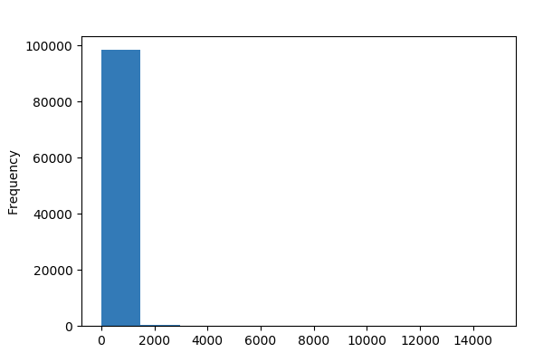

**Common Values**

| Value | Count | Frequency (%) |  |
| --- | --- | --- | --- |
| 0 | 60999 | 61.6% |  |
| 1 | 4697 | 4.7% |  |
| 2 | 2760 | 2.8% |  |
| 3 | 1948 | 2.0% |  |
| 4 | 1419 | 1.4% |  |
| 5 | 1202 | 1.2% |  |
| 6 | 1081 | 1.1% |  |
| 7 | 897 | 0.9% |  |
| 8 | 792 | 0.8% |  |
| 9 | 757 | 0.8% |  |
| Other values (1716) | 22451 | 22.7% |  |

**Extreme Values**

Minimum 5 values

| Value | Count | Frequency (%) |  |
| --- | --- | --- | --- |
| 0 | 60999 | 61.6% |  |
| 1 | 4697 | 4.7% |  |
| 2 | 2760 | 2.8% |  |
| 3 | 1948 | 2.0% |  |
| 4 | 1419 | 1.4% |  |

Maximum 5 values

| Value | Count | Frequency (%) |  |
| --- | --- | --- | --- |
| 10627 | 1 | 0.0% |  |
| 10763 | 1 | 0.0% |  |
| 11077 | 1 | 0.0% |  |
| 12903 | 1 | 0.0% |  |
| 14865 | 1 | 0.0% |  |

www_likes_received  
Highly correlated

*This variable is highly correlated with `likes_received` and should be ignored for analysis*

| Correlation | 0.94799 |
| --- | --- |

Correlations

[2 more figures not shown]

Sample

|  | userid | age | dob_day | dob_year | dob_month | gender | tenure | friend_count | friendships_initiated | likes | likes_received | mobile_likes | mobile_likes_received | www_likes | www_likes_received | Mobile_Total_Likes | Desktop_Total_Likes | Total_Likes_Send | Total_Likes_Received |
| --- | --- | --- | --- | --- | --- | --- | --- | --- | --- | --- | --- | --- | --- | --- | --- | --- | --- | --- | --- |
| 0 | 2094382 | 14 | 19 | 1999 | 11 | male | 266.0 | 0 | 0 | 0 | 0 | 0 | 0 | 0 | 0 | 0 | 0 | 0 | 0 |
| 1 | 1192601 | 14 | 2 | 1999 | 11 | female | 6.0 | 0 | 0 | 0 | 0 | 0 | 0 | 0 | 0 | 0 | 0 | 0 | 0 |
| 2 | 2083884 | 14 | 16 | 1999 | 11 | male | 13.0 | 0 | 0 | 0 | 0 | 0 | 0 | 0 | 0 | 0 | 0 | 0 | 0 |
| 3 | 1203168 | 14 | 25 | 1999 | 12 | female | 93.0 | 0 | 0 | 0 | 0 | 0 | 0 | 0 | 0 | 0 | 0 | 0 | 0 |
| 4 | 1733186 | 14 | 4 | 1999 | 12 | male | 82.0 | 0 | 0 | 0 | 0 | 0 | 0 | 0 | 0 | 0 | 0 | 0 | 0 |

```python
pandas_profiling.ProfileReport(fbd)
```

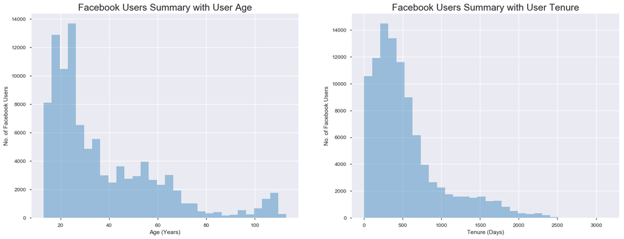

```python
# Analysis for friend_count and gender dataset by histro-graph.
plt.figure(figsize=(20,7))

plt.subplot(1,2,1)
sns.distplot(fbd['age'], bins = 30, kde = False)
plt.xlabel('Age (Years)')
plt.ylabel('No. of Facebook Users')
plt.title('Facebook Users Summary with User Age', fontsize=18)

plt.subplot(1,2,2)
sns.distplot(fbd['tenure'], bins = 30, kde = False)
plt.xlabel('Tenure (Days)')
plt.ylabel('No. of Facebook Users')
plt.title('Facebook Users Summary with User Tenure', fontsize=18)

plt.show()
```

<font color=green> **Observation:** Almost 95 % of Age and Tenure samples are below 90 Years and 2000 Days respectivelly. Age > 100 Yrs and Tenure > 2000 Days seems outliers.</font>

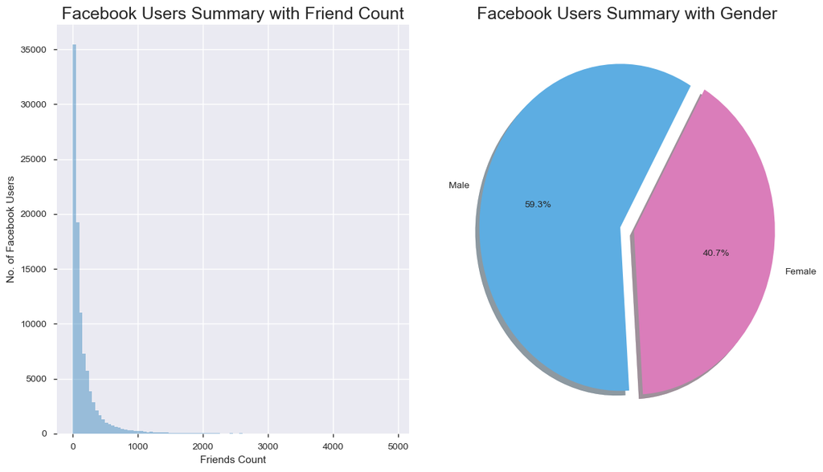

```python
# Analysis for friend_count and gender dataset by histro-graph and pie chart.
plt.figure(figsize=(12,7))

plt.subplot(1,2,1)
sns.distplot(fbd['friend_count'], bins = 100, kde = False)
plt.xlabel('Friends Count')
plt.ylabel('No. of Facebook Users')
plt.title('Facebook Users Summary with Friend Count', fontsize=18)

plt.subplot(1,2,2)
labels = ['Male', 'Female']
sizes = fbd.gender.value_counts()
colors = ['#5DADE2', '#DA7DBA']
explode = (0.05, 0.05)
plt.pie(sizes, labels=labels, explode=explode, colors=colors, autopct='%1.1f%%', shadow=True, startangle=60)
plt.title('Facebook Users Summary with Gender', fontsize=18)

plt.tight_layout()
plt.show()
```

<font color=green> **Observation:** Almost 95 % of Friends_Count are below 1000 and mejority (59.3%) of Facebook users are Male as comparing to Females. </font>

## Assumption-2:

Removed outliers on the basis of non-active users (whose tenure > 30 days & friend's count = 0 & TotalLikesSend = 0)

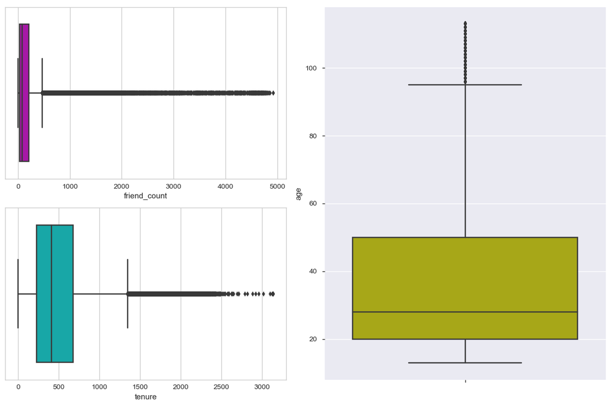

```python
# Box-plot ananlysis for age, tenure and frient_count outliers.
fig = plt.figure(figsize=(12,8))

plt.subplot(1,2,2)
sns.set_style("whitegrid")
sns.boxplot(y='age', data=fbd, color='y')

plt.subplot(2,2,3)
sns.set_style("whitegrid")
sns.boxplot(x='tenure', data=fbd, color='c')

plt.subplot(2,2,1)
sns.set_style("whitegrid")
sns.boxplot(x='friend_count', data=fbd, color='m')

plt.tight_layout()
plt.show()
```

```python
# Defining function to find outliers from facebook dataset.
def detect_outliers(col,length):
    q1 = np.percentile(fbd[col],25)
    q3 = np.percentile(fbd[col],75)
    IQR = q3-q1

    # outlier step
    outlier_step = 1.5*IQR

    # Determining the list of indices of outliers for each feature column.
    outlier_list_col = fbd[(fbd[col] < q1 - outlier_step) | (fbd[col] > q3 + outlier_step)].index

    return outlier_list_col
```

```python
# Removing outliers in age column (users with age > 100 years, which seems not valid).
Age_Outliers_drop = detect_outliers('age',1.5)
fbd_Age_drop = fbd.drop(fbd.index[Age_Outliers_drop])
fbd = fbd_Age_drop
fbd.info()
```

```
<class 'pandas.core.frame.DataFrame'>
Int64Index: 94689 entries, 0 to 99002
Data columns (total 19 columns):
userid                   94689 non-null int64
age                      94689 non-null int64
dob_day                  94689 non-null int64
dob_year                 94689 non-null int64
dob_month                94689 non-null int64
gender                   94689 non-null object
tenure                   94689 non-null float64
friend_count             94689 non-null int64
friendships_initiated    94689 non-null int64
likes                    94689 non-null int64
likes_received           94689 non-null int64
mobile_likes             94689 non-null int64
mobile_likes_received    94689 non-null int64
www_likes                94689 non-null int64
www_likes_received       94689 non-null int64
Mobile_Total_Likes       94689 non-null int64
Desktop_Total_Likes      94689 non-null int64
Total_Likes_Send         94689 non-null int64
Total_Likes_Received     94689 non-null int64
dtypes: float64(1), int64(17), object(1)
memory usage: 14.4+ MB
```

```python
# Reindexing the data after removing rows from age column
fbd.reset_index(drop=True, inplace=True)
```

```python
# Description and Distribution Analysis-3: Details of modified data after removing age outliers
fbd.describe()
```

|  | userid | age | dob_day | dob_year | dob_month | tenure | friend_count | friendships_initiated | likes | likes_received | mobile_likes | mobile_likes_received | www_likes | www_likes_received | Mobile_Total_Likes | Desktop_Total_Likes | Total_Likes_Send | Total_Likes_Received |
| --- | --- | --- | --- | --- | --- | --- | --- | --- | --- | --- | --- | --- | --- | --- | --- | --- | --- | --- |
| count | 9.468900e+04 | 94689.000000 | 94689.000000 | 94689.000000 | 94689.000000 | 94689.000000 | 94689.000000 | 94689.000000 | 94689.000000 | 94689.000000 | 94689.000000 | 94689.000000 | 94689.000000 | 94689.000000 | 94689.000000 | 94689.000000 | 94689.000000 | 94689.000000 |
| mean | 1.597239e+06 | 34.194268 | 14.531181 | 1978.805732 | 6.285577 | 512.013158 | 187.205811 | 103.655314 | 156.273031 | 143.121778 | 106.572833 | 84.177814 | 49.700134 | 58.943922 | 190.750647 | 108.644056 | 156.272967 | 143.121735 |
| std | 3.441140e+05 | 17.729108 | 8.993114 | 17.729108 | 3.522052 | 431.609496 | 373.920512 | 184.945801 | 577.365956 | 1414.113509 | 448.769500 | 852.926814 | 288.504027 | 614.112766 | 1070.048450 | 751.598879 | 577.365836 | 1414.113453 |
| min | 1.000008e+06 | 13.000000 | 1.000000 | 1918.000000 | 1.000000 | 0.000000 | 0.000000 | 0.000000 | 0.000000 | 0.000000 | 0.000000 | 0.000000 | 0.000000 | 0.000000 | 0.000000 | 0.000000 | 0.000000 | 0.000000 |
| 25% | 1.299041e+06 | 20.000000 | 7.000000 | 1967.000000 | 3.000000 | 221.000000 | 30.000000 | 16.000000 | 1.000000 | 0.000000 | 0.000000 | 0.000000 | 0.000000 | 0.000000 | 1.000000 | 0.000000 | 1.000000 | 0.000000 |
| 50% | 1.596341e+06 | 27.000000 | 14.000000 | 1986.000000 | 6.000000 | 401.000000 | 78.000000 | 44.000000 | 10.000000 | 8.000000 | 4.000000 | 4.000000 | 0.000000 | 2.000000 | 12.000000 | 4.000000 | 10.000000 | 8.000000 |
| 75% | 1.896064e+06 | 46.000000 | 22.000000 | 1993.000000 | 9.000000 | 644.000000 | 196.000000 | 111.000000 | 79.000000 | 57.000000 | 45.000000 | 32.000000 | 6.000000 | 19.000000 | 89.000000 | 35.000000 | 79.000000 | 57.000000 |
| max | 2.193542e+06 | 95.000000 | 31.000000 | 2000.000000 | 12.000000 | 2697.000000 | 4917.000000 | 4144.000000 | 25111.000000 | 261197.000000 | 25111.000000 | 138561.000000 | 14865.000000 | 129953.000000 | 140543.000000 | 130310.000000 | 25111.000000 | 261197.000000 |

```python
# Conversion of age column into groups for better visualization and analysis.
indices=[]
tIndices=[]
yIndices=[]
adoIndices=[]
adltIndices=[]
midageIndices=[]
sIndices=[]

for index, row in fbd.iterrows():
    if row['age']<13:
        indices.append(index)

    elif row['age']>=13 and row['age']<20:
        tIndices.append(index)

    elif row['age']>=20 and row['age']<25:
        yIndices.append(index)

    elif row['age']>=25 and row['age']<30:
        adoIndices.append(index)

    elif row['age']>=30 and row['age']<40:
        adltIndices.append(index)

    elif row['age']>=40 and row['age']<60:
        midageIndices.append(index)

    else:
        sIndices.append(index)
```

```python
# Categorically, age has been grouped in age_group column into child, teenagers, youngsters, adolescents, adults, mid-aged and senior-citizen based on some assumptions.
def age_group(row):
  if row['age'] < 13 :
     return 'Children'
  if row['age'] >= 13 and row['age'] < 20 :
     return 'Teenagers'
  if row['age'] >= 20 and row['age'] < 26 :
     return 'Youngsters'
  if row['age'] >= 26 and row['age'] < 31:
     return 'Adolescents'
  if row['age'] >= 31 and row['age'] < 41:
     return 'Adults'
  if row['age'] >= 41 and row['age'] < 61:
     return 'Mid-Aged'
  if row['age']  >= 61:
     return 'Senior-Citizen'

fbd['Age_Group'] = fbd.apply(lambda row: age_group(row),axis=1)
fbd.reset_index(drop=True, inplace=True)
fbd.info()

# infant (birth-12 months)
# toddler (1-4 years)
# child (5-11 years)
# preteen (12 years)
# teenager (13-19 years)
# youngster (20-25 years)
# adolescents (26-30 years)
# adult (31-40 years)
# mid-aged (41-60 years)
# senior citizen (60+ years)
```

```
<class 'pandas.core.frame.DataFrame'>
RangeIndex: 94689 entries, 0 to 94688
Data columns (total 20 columns):
userid                   94689 non-null int64
age                      94689 non-null int64
dob_day                  94689 non-null int64
dob_year                 94689 non-null int64
dob_month                94689 non-null int64
gender                   94689 non-null object
tenure                   94689 non-null float64
friend_count             94689 non-null int64
friendships_initiated    94689 non-null int64
likes                    94689 non-null int64
likes_received           94689 non-null int64
mobile_likes             94689 non-null int64
mobile_likes_received    94689 non-null int64
www_likes                94689 non-null int64
www_likes_received       94689 non-null int64
Mobile_Total_Likes       94689 non-null int64
Desktop_Total_Likes      94689 non-null int64
Total_Likes_Send         94689 non-null int64
Total_Likes_Received     94689 non-null int64
Age_Group                94689 non-null object
dtypes: float64(1), int64(17), object(2)
memory usage: 14.4+ MB
```

```python
# Facebook data with age-gropus.
childernData = pd.DataFrame(fbd.ix[indices], columns = fbd.keys()).reset_index(drop=True)
teenagersData = pd.DataFrame(fbd.ix[tIndices], columns = fbd.keys()).reset_index(drop=True)
youngestersData = pd.DataFrame(fbd.ix[yIndices], columns = fbd.keys()).reset_index(drop=True)
adolescentsData = pd.DataFrame(fbd.ix[adoIndices], columns = fbd.keys()).reset_index(drop=True)
adltsData = pd.DataFrame(fbd.ix[adltIndices], columns = fbd.keys()).reset_index(drop=True)
midageData = pd.DataFrame(fbd.ix[midageIndices], columns = fbd.keys()).reset_index(drop=True)
sData = pd.DataFrame(fbd.ix[sIndices], columns = fbd.keys()).reset_index(drop=True)
```